# Biostat776project3

```r
ts_lyrics_tb1 <-  unnest_tokens(ts_lyrics,
    output = lines,
    input = Lyrics,
    token = "lines")
dim(ts_lyrics)
```

```
## [1] 132   4
```

```r
dim(ts_lyrics_tb1)
```

```
## [1] 6955    4
```

```r
#how many hello?
ts_hello <- ts_lyrics_tb1 %>%
  filter(str_detect(lines, "hello"))
ts_hello
```

```
## # A tibble: 6 × 4
##   Artist       Album    Title                  lines
##   <chr>        <chr>    <chr>                  <chr>
## 1 Taylor Swift Fearless Love Story             "and say, \"hello\""
## 2 Taylor Swift Red      I Almost Do            "that i can't say \"hello\" to y…
## 3 Taylor Swift Red      Everything Has Changed "'cause all i know is we said he…
## 4 Taylor Swift Red      Everything Has Changed "'cause all i know is we said he…
## 5 Taylor Swift Red      Everything Has Changed "all i know is we said hello"
## 6 Taylor Swift Red      Everything Has Changed "all i know is we said hello"
```

```r
ts_hello %>%
  count()
```

```
## # A tibble: 1 × 1
##       n
##   <int>
## 1     6
```

```r
# how many goodbye?
ts_goodbye <- ts_lyrics_tb1 %>%
  filter(str_detect(lines, "goodbye")) %>%
  head()
ts_goodbye
```

```
## # A tibble: 6 × 4
##   Artist       Album        Title                      lines
##   <chr>        <chr>        <chr>                      <chr>
## 1 Taylor Swift Taylor Swift Tied Together With A Smile goodbye, baby
## 2 Taylor Swift Speak Now    Mine                       braced myself for the go…
## 3 Taylor Swift Speak Now    Back to December           you gave me all your lov…
## 4 Taylor Swift Speak Now    Long Live                  and force us into a good…
## 5 Taylor Swift Red          I Almost Do                and risk another goodbye
## 6 Taylor Swift Red          Come Back Be Here          stumbled through the lon…
```

```r
ts_goodbye %>%
  count()
```

```
## # A tibble: 1 × 1
##       n
##   <int>
## 1     6
```

##Part 2B Repeat the same analysis for b_lyrics as described in Part 2A.

```r
class(b_lyrics)
```

```
## [1] "spec_tbl_df" "tbl_df"      "tbl"         "data.frame"
```

```r
glimpse(b_lyrics)
```

```
## Rows: 22,616
## Columns: 6
## $ line        <chr> "If I ain't got nothing, I got you", "If I ain't got somet…
## $ song_id     <dbl> 50396, 50396, 50396, 50396, 50396, 50396, 50396, 50396, 50…
## $ song_name   <chr> "1+1", "1+1", "1+1", "1+1", "1+1", "1+1", "1+1", "1+1", "1…
## $ artist_id   <dbl> 498, 498, 498, 498, 498, 498, 498, 498, 498, 498, 498, 498…
## $ artist_name <chr> "Beyoncé", "Beyoncé", "Beyoncé", "Beyoncé", "Beyoncé", "Be…
## $ song_line   <dbl> 1, 2, 3, 4, 5, 6, 7, 8, 9, 10, 11, 12, 13, 14, 15, 16, 17,…
```

```r
b_lyrics_tb1 <- b_lyrics
#how many hello?
b_hello <- b_lyrics_tb1 %>%
  filter(str_detect(line, "hello"))
b_hello
```

```
## # A tibble: 32 × 6
##    line                        song_id song_name artist_id artist_name song_line
##    <chr>                         <dbl> <chr>         <dbl> <chr>           <dbl>
##  1 Fellow great Americans, he… 2715227 FREEDOM …       498 Beyoncé            52
##  2 You had me at hello (Hello)   80249 Hello           498 Beyoncé            15
##  3 You had me at hello (Hello)   80249 Hello           498 Beyoncé            18
##  4 'Cause you had me at hello…   80249 Hello           498 Beyoncé            24
##  5 You had me at hello (Hello)   80249 Hello           498 Beyoncé            41
##  6 You had me at hello (Hello)   80249 Hello           498 Beyoncé            44
##  7 You had me at hello (Hello)   80249 Hello           498 Beyoncé            50
##  8 Hello (Hello, hello)          80249 Hello           498 Beyoncé            52
##  9 You had me at hello (Hello)   80249 Hello           498 Beyoncé            62
## 10 You had me at hello (Hello)   80249 Hello           498 Beyoncé            65
## # ℹ 22 more rows
```

```r
b_hello %>%
  count()
```

```
## # A tibble: 1 × 1
##       n
##   <int>
## 1    32
```

```r
#how many goodbye?
b_goodbye <- b_lyrics_tb1 %>%
  filter(str_detect(line, "goodbye"))
b_goodbye
```

```
## # A tibble: 12 × 6
##    line                        song_id song_name artist_id artist_name song_line
##    <chr>                         <dbl> <chr>         <dbl> <chr>           <dbl>
##  1 We only said goodbye with …  139043 Back to …       498 Beyoncé            12
##  2 We only said goodbye with …  139043 Back to …       498 Beyoncé            21
##  3 We only said goodbye with …  139043 Back to …       498 Beyoncé            24
##  4 Thank God, I found the goo…   51492 Best Thi…       498 Beyoncé            38
##  5 Thank God, I found the goo… 1946060 Best Thi…       498 Beyoncé            42
##  6 Thank God, I found the goo… 4241137 Best Thi…       498 Beyoncé            38
##  7 It's so hard to say goodbye  435491 Gift fro…       498 Beyoncé            23
##  8 I never want to say goodbye  435491 Gift fro…       498 Beyoncé            24
##  9 I never, ever want to say …  435491 Gift fro…       498 Beyoncé            25
## 10 We've got to say goodbye    1844620 Hard To …       498 Beyoncé            29
## 11 Don't have to say goodbye   1224115 Slow Love       498 Beyoncé            42
## 12 Somewhere between hi and g…  141848 Yes             498 Beyoncé            27
```

```r
b_goodbye %>%
  count()
```

```
## # A tibble: 1 × 1
##       n
##   <int>
## 1    12
```

##Part 2C Using the b_lyrics dataset, Tokenize each lyrical line by words. Remove the “stopwords”. Calculate the total number for each word in the lyrics. Using the “bing” sentiment lexicon, add a column to the summarized data frame adding the “bing” sentiment lexicon. Sort the rows from most frequent to least frequent words. Only keep the top 25 most frequent words. Auto print the wrangled tibble data frame. Use ggplot2 to create a bar plot with the top words on the y-axis and the frequency of each word on the x-axis. Color each bar by the sentiment of each word from the “bing” sentiment lexicon. Bars should be ordered from most frequent on the top to least frequent on the bottom of the plot. Create a word cloud of the top 25 most frequent words.

```r
library(dplyr)
b_lyrics_tb2 <-  b_lyrics_tb1 %>%
  unnest_tokens(
    output = word,
    input = line) %>%
  anti_join(get_stopwords()) %>%
  count(word, sort = TRUE) %>%
 inner_join(get_sentiments("bing")) %>%
  head(n=25)
print(b_lyrics_tb2, n = dim(b_lyrics_tb2)[1])
```

```
## # A tibble: 25 × 3
##    word          n sentiment
##    <chr>     <int> <chr>
##  1 like       1376 positive
##  2 love       1362 positive
##  3 right       464 positive
##  4 good        361 positive
##  5 crazy       308 negative
##  6 top         241 positive
##  7 work        236 positive
##  8 bad         132 negative
##  9 beautiful   131 positive
## 10 whoa        121 positive
## 11 best        119 positive
## 12 better      113 positive
## 13 damn        106 negative
## 14 hurt         90 negative
## 15 hard         87 negative
## 16 ready        85 positive
## 17 sweet        84 positive
## 18 sorry        81 negative
## 19 cool         76 positive
## 20 enough       75 positive
## 21 gold         75 positive
## 22 broken       72 negative
## 23 damned       72 negative
## 24 loving       72 positive
## 25 promise      69 positive
```

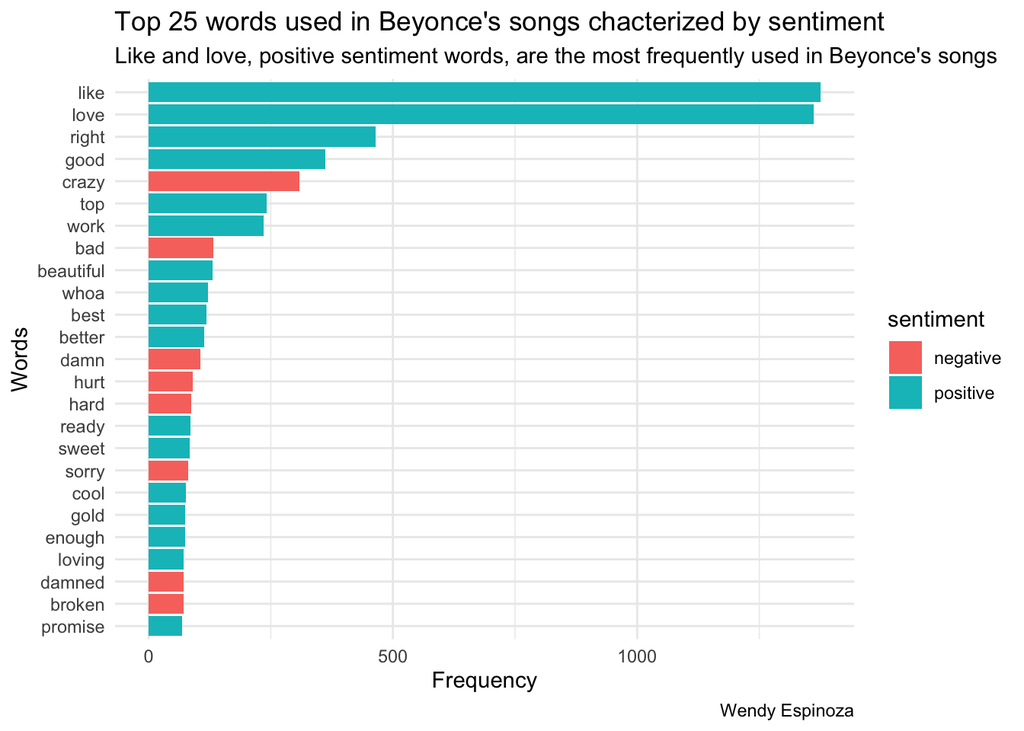

```r
#plot
graph4 <- b_lyrics_tb2 %>%
  mutate(this = fct_reorder(.f= word, .x = n)) %>%
  ggplot(aes(x = n, y= this, fill = sentiment)) +
  geom_bar(stat= "identity") +
  theme_minimal()+
  labs(title = "Top 25 words used in Beyonce's songs chacterized by sentiment", subtitle = "Like and love, positive sentiment words, are the most frequently used in Beyonce's songs", x = "Frequency", y = "Words", caption = "Wendy Espinoza")
 print(graph4)
```

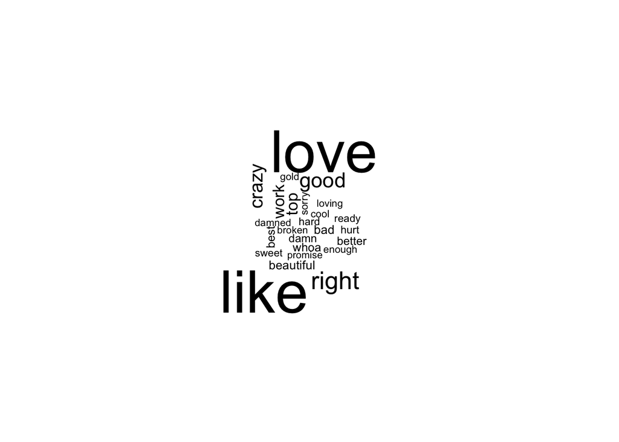

```r
#word clouds
library(RColorBrewer)
library(wordcloud)
b_lyrics_tb2 %>%
    with(wordcloud(word, n))
```

##Part 2D Repeat the same analysis as above in Part 2C, but for ts_lyrics.

```r
library(dplyr)
library(textdata)


ts_lyrics_tb2 <-  ts_lyrics_tb1 %>%
  unnest_tokens(
    output = word,
    input = lines) %>%
  anti_join(get_stopwords()) %>%
  count(word, sort = TRUE) %>%
 inner_join(get_sentiments("bing")) %>%
  head(n=25)
print(ts_lyrics_tb2, n = dim(ts_lyrics_tb2)[1])
```

```
## # A tibble: 25 × 3
##    word          n sentiment
##    <chr>     <int> <chr>
##  1 like        406 positive
##  2 love        248 positive
##  3 right       110 positive
##  4 bad          80 negative
##  5 good         76 positive
##  6 better       74 positive
##  7 shake        73 negative
##  8 break        59 negative
##  9 best         52 positive
## 10 mad          48 negative
## 11 beautiful    46 positive
## 12 smile        45 positive
## 13 hate         44 negative
## 14 fall         43 negative
## 15 clear        41 positive
## 16 sorry        36 negative
## 17 whoa         36 positive
## 18 well         34 positive
## 19 lost         33 negative
## 20 nice         32 positive
## 21 trouble      32 negative
## 22 enough       31 positive
## 23 miss         31 negative
## 24 wrong        31 negative
## 25 darling      30 positive
```

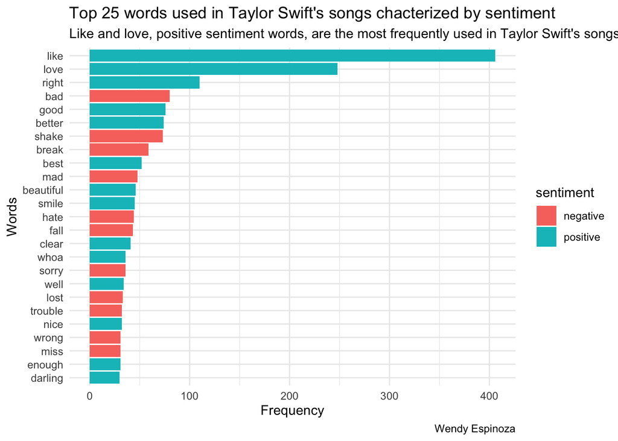

```r
#plot
graph5 <- ts_lyrics_tb2 %>%
  mutate(this = fct_reorder(.f= word, .x = n)) %>%
  ggplot(aes(x = n, y= this, fill = sentiment)) +
  geom_bar(stat= "identity") +
  theme_minimal()+
  labs(title = "Top 25 words used in Taylor Swift's songs chacterized by sentiment", subtitle = "Like and love, positive sentiment words, are the most frequently used in Taylor Swift's songs", x = "Frequency", y = "Words", caption = "Wendy Espinoza")

print(graph5)
```